# Practice 1 from QUT Tutorial

# Exercise 0: Installing Packages

Use install.packages to install packages which are needed.

```r
# You can go ahead and run this - you'll need it later in the lab!
install.packages("ggplot2")
install.packages("reshape2")
```

Use library to tell R which packages you are going to use.

```r
# Go ahead and run this as well
library(ggplot2)
library(reshape2)
```

# Exercise 1: The purpose of plotting

Read CSV file by read.csv and show the plots by plot function.

```r
# Use this space to load the data frames (i.e. put the data frame load instruction below):
q1 <- read.csv("Practice/quartet_data/quartet1.csv")
q2 <- read.csv("Practice/quartet_data/quartet2.csv")
q3 <- read.csv("Practice/quartet_data/quartet3.csv")
q4 <- read.csv("Practice/quartet_data/quartet4.csv")
# Display all four plots in the same window (You don't need to know this)
par(mfrow=c(2,2))
# Complete these plots:
plot(q1)
plot(q2)
```

[figure not shown]

```r
plot(q3)
plot(q4)
```

# Exercise 2: Plotting from a CSV file

Read the rent.csv, it contains the rent price of each types of houses in Au.

```r
rent <- read.csv("Practice/archive/rent.csv")
```

Use summary function to show the summary info of data.

```r
# Write your functions and your notes regarding these functions in this space here
summary(rent)
```

[output not shown]

Use aggregate function to find the mean price of each types of houses.

```r
avg_rent <- aggregate(x=list(rent=rent$weekly_rent), FUN=mean, by=list(dwelling_type=rent$dwelling_type))
print(avg_rent)
```

[output not shown]

Use barplot function to show a bar chart of the price of each types.

```r
# Write your solution to plot the data here!
barplot(avg_rent$rent, names=avg_rent$dwelling_type, las=2, ylab="Avg($)")
```

[output not shown]

# Exercise 3: Further exploration

Use aggregate again, but this time, use type and location to group by. Then use acast and data.frame function to creat a 2 dimemsion matrix. Third step - use is.na function to make NA become 0.

```r
# Calculate the rent for each dwelling type in a locality
avg_bylocal <- aggregate(list(rent=rent$weekly_rent), FUN=mean, by=list(locality=rent$locality, dwelling_type=rent$dwelling_type))
head(avg_bylocal)
# Manipulate the data
library(reshape2)
rent_matrix <- acast(avg_bylocal, dwelling_type~locality, value.var = "rent")
rent_matrix <- data.frame(rent_matrix)
rent_matrix[is.na(rent_matrix)] <- 0
rent_matrix <- as.matrix(rent_matrix, dtype="float")

# Set colnames and rownames
colnames(rent_matrix) = levels(avg_bylocal$locality)
rownames(rent_matrix) = levels(avg_bylocal$dwelling_type)
print(rent_matrix)
# Plot the data
barplot(rent_matrix, las=2, beside = TRUE, col = rainbow(length(rownames(rent_matrix))))
legend("topright", legend = rownames(rent_matrix), fill = rainbow(length(rownames(rent_matrix))), cex = 0.6)
```

[output not shown]

# Exercise 4: Effective ggplot2

Use ggplot2 to show the charts.

```r
# Re-do exercise 1 here
library(ggplot2)
library(reshape2)
q1 <- read.csv("Practice/quartet_data/quartet1.csv", col.names = c("x", "y", "A"))
```

```
header and 'col.names' are of different lengths
```

```r
q2 <- read.csv("Practice/quartet_data/quartet2.csv", col.names = c("x", "y", "B"))
```

```
header and 'col.names' are of different lengths
```

```r
q3 <- read.csv("Practice/quartet_data/quartet3.csv", col.names = c("x", "y", "C"))
```

```
header and 'col.names' are of different lengths
```

```r
q4 <- read.csv("Practice/quartet_data/quartet4.csv", col.names = c("x", "y", "D"))
```

```
header and 'col.names' are of different lengths
```

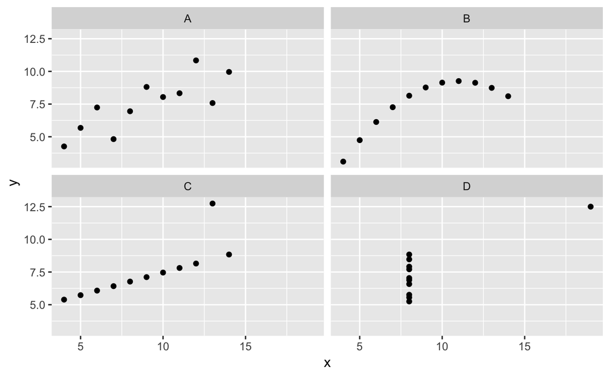

```r
#多個col轉成一個col, 留下Ａ？
m1 <- melt(q1, measure.vars = "A")
m2 <- melt(q2, measure.vars = "B")
m3 <- melt(q3, measure.vars = "C")
m4 <- melt(q4, measure.vars = "D")
agg <- rbind(m1, m2, m3, m4)
# aesesis => Data與圖形之間的關係，指定哪個要Ｘ哪個Ｙ
# geometry => 指定要用什麼圖形畫出來
# Facet => 讓圖形分散在多張子圖
ggplot(agg, aes(x=x, y=y)) + geom_point() + facet_wrap(~variable)
```

Same, use aggregate to find the ‘mean’ of prices. Then, use ggplot, geom_bar, and theme function to show a bar chart.

```r
# Re-do exercise 2 here
avg_rent <- aggregate(x=list(rent=rent$weekly_rent), FUN=mean, by=list(dwelling_type=rent$dwelling_type))
ggplot(avg_rent, aes(x=dwelling_type, y=rent)) + geom_bar(stat="identity") + theme(axis.text = element_text(angle=90, hjust=1))
```

[output not shown]

Same, use location and type to group by and try to do exercise 3 again by ggplot2.

```r
# Re-do exercise 3 here
avg_bylocal <- aggregate(list(rent=rent$weekly_rent), FUN=mean, by=list(locality=rent$locality, dwelling_type=rent$dwelling_type))

ggplot(avg_bylocal, aes(x=locality, y=rent, fill=dwelling_type)) + geom_bar(stat = "identity", position = "dodge") + theme(axis.text.x = element_text(angle=90, hjust=1))
```

[output not shown]

How did you find completing the exercises again but using `ggplot`? From now on you may use any plotting library you like. We recommend that you stick with `ggplot` as it is by far the easiest and most well-documented plotting library for R.